# Risk Factor Analysis

## Outcome Variable

**Outcome Variable:** ever_stunted

## Predictor Variables

**Intervention Variable:** mhtcm

**Adjustment Set:**

unadjusted

## Stratifying Variables

The analysis was stratified on these variable(s):

- agecat
- studyid
- country

## Data Summary

| agecat | studyid | country | A | n | nA | nAY0 | nAY1 |
| --- | --- | --- | --- | --- | --- | --- | --- |
| 3 months | ki0047075b-MAL-ED | BANGLADESH | >=160 | 254 | 4 | 4 | 0 |
| 3 months | ki0047075b-MAL-ED | BANGLADESH | <145 | 254 | 56 | 32 | 24 |
| 3 months | ki0047075b-MAL-ED | BANGLADESH | [145-150) | 254 | 91 | 63 | 28 |
| 3 months | ki0047075b-MAL-ED | BANGLADESH | [150-155) | 254 | 82 | 66 | 16 |
| 3 months | ki0047075b-MAL-ED | BANGLADESH | [155-160) | 254 | 21 | 17 | 4 |
| 3 months | ki0047075b-MAL-ED | BRAZIL | >=160 | 222 | 68 | 61 | 7 |
| 3 months | ki0047075b-MAL-ED | BRAZIL | <145 | 222 | 8 | 7 | 1 |
| 3 months | ki0047075b-MAL-ED | BRAZIL | [145-150) | 222 | 33 | 27 | 6 |
| 3 months | ki0047075b-MAL-ED | BRAZIL | [150-155) | 222 | 51 | 41 | 10 |
| 3 months | ki0047075b-MAL-ED | BRAZIL | [155-160) | 222 | 62 | 51 | 11 |
| 3 months | ki0047075b-MAL-ED | INDIA | >=160 | 242 | 14 | 12 | 2 |
| 3 months | ki0047075b-MAL-ED | INDIA | <145 | 242 | 29 | 21 | 8 |
| 3 months | ki0047075b-MAL-ED | INDIA | [145-150) | 242 | 70 | 49 | 21 |
| 3 months | ki0047075b-MAL-ED | INDIA | [150-155) | 242 | 88 | 63 | 25 |
| 3 months | ki0047075b-MAL-ED | INDIA | [155-160) | 242 | 41 | 32 | 9 |
| 3 months | ki0047075b-MAL-ED | NEPAL | >=160 | 238 | 5 | 5 | 0 |
| 3 months | ki0047075b-MAL-ED | NEPAL | <145 | 238 | 37 | 25 | 12 |
| 3 months | ki0047075b-MAL-ED | NEPAL | [145-150) | 238 | 86 | 77 | 9 |
| 3 months | ki0047075b-MAL-ED | NEPAL | [150-155) | 238 | 74 | 61 | 13 |
| 3 months | ki0047075b-MAL-ED | NEPAL | [155-160) | 238 | 36 | 33 | 3 |
| 3 months | ki0047075b-MAL-ED | PERU | >=160 | 290 | 12 | 8 | 4 |
| 3 months | ki0047075b-MAL-ED | PERU | <145 | 290 | 42 | 21 | 21 |
| 3 months | ki0047075b-MAL-ED | PERU | [145-150) | 290 | 108 | 69 | 39 |
| 3 months | ki0047075b-MAL-ED | PERU | [150-155) | 290 | 80 | 55 | 25 |
| 3 months | ki0047075b-MAL-ED | PERU | [155-160) | 290 | 48 | 37 | 11 |
| 3 months | ki0047075b-MAL-ED | SOUTH AFRICA | >=160 | 270 | 121 | 97 | 24 |
| 3 months | ki0047075b-MAL-ED | SOUTH AFRICA | <145 | 270 | 9 | 5 | 4 |
| 3 months | ki0047075b-MAL-ED | SOUTH AFRICA | [145-150) | 270 | 14 | 9 | 5 |
| 3 months | ki0047075b-MAL-ED | SOUTH AFRICA | [150-155) | 270 | 43 | 29 | 14 |
| 3 months | ki0047075b-MAL-ED | SOUTH AFRICA | [155-160) | 270 | 83 | 58 | 25 |

[output cut: 500 more lines]

The following strata were considered:

- agecat: 12 months, studyid: ki0047075b-MAL-ED, country: BANGLADESH
- agecat: 12 months, studyid: ki0047075b-MAL-ED, country: BRAZIL
- agecat: 12 months, studyid: ki0047075b-MAL-ED, country: INDIA
- agecat: 12 months, studyid: ki0047075b-MAL-ED, country: NEPAL
- agecat: 12 months, studyid: ki0047075b-MAL-ED, country: PERU
- agecat: 12 months, studyid: ki0047075b-MAL-ED, country: SOUTH AFRICA
- agecat: 12 months, studyid: ki0047075b-MAL-ED, country: TANZANIA, UNITED REPUBLIC OF
- agecat: 12 months, studyid: ki1000304b-SAS-CompFeed, country: INDIA
- agecat: 12 months, studyid: ki1000304b-SAS-FoodSuppl, country: INDIA
- agecat: 12 months, studyid: ki1017093-NIH-Birth, country: BANGLADESH
- agecat: 12 months, studyid: ki1017093b-PROVIDE, country: BANGLADESH
- agecat: 12 months, studyid: ki1017093c-NIH-Crypto, country: BANGLADESH
- agecat: 12 months, studyid: ki1066203-TanzaniaChild2, country: TANZANIA, UNITED REPUBLIC OF
- agecat: 12 months, studyid: ki1101329-Keneba, country: GAMBIA
- agecat: 12 months, studyid: ki1112895-Guatemala BSC, country: GUATEMALA
- agecat: 12 months, studyid: ki1112895-iLiNS-Zinc, country: BURKINA FASO
- agecat: 12 months, studyid: ki1119695-PROBIT, country: BELARUS
- agecat: 12 months, studyid: ki1126311-ZVITAMBO, country: ZIMBABWE
- agecat: 12 months, studyid: ki1135781-COHORTS, country: GUATEMALA
- agecat: 12 months, studyid: ki1135781-COHORTS, country: INDIA
- agecat: 12 months, studyid: ki1135781-COHORTS, country: PHILIPPINES
- agecat: 12 months, studyid: ki1148112-LCNI-5, country: MALAWI
- agecat: 12 months, studyid: kiGH5241-JiVitA-3, country: BANGLADESH
- agecat: 18 months, studyid: ki0047075b-MAL-ED, country: BANGLADESH
- agecat: 18 months, studyid: ki0047075b-MAL-ED, country: BRAZIL
- agecat: 18 months, studyid: ki0047075b-MAL-ED, country: INDIA
- agecat: 18 months, studyid: ki0047075b-MAL-ED, country: NEPAL
- agecat: 18 months, studyid: ki0047075b-MAL-ED, country: PERU
- agecat: 18 months, studyid: ki0047075b-MAL-ED, country: SOUTH AFRICA
- agecat: 18 months, studyid: ki0047075b-MAL-ED, country: TANZANIA, UNITED REPUBLIC OF
- agecat: 18 months, studyid: ki1000304b-SAS-CompFeed, country: INDIA
- agecat: 18 months, studyid: ki1000304b-SAS-FoodSuppl, country: INDIA
- agecat: 18 months, studyid: ki1017093-NIH-Birth, country: BANGLADESH
- agecat: 18 months, studyid: ki1017093b-PROVIDE, country: BANGLADESH
- agecat: 18 months, studyid: ki1017093c-NIH-Crypto, country: BANGLADESH
- agecat: 18 months, studyid: ki1066203-TanzaniaChild2, country: TANZANIA, UNITED REPUBLIC OF
- agecat: 18 months, studyid: ki1101329-Keneba, country: GAMBIA
- agecat: 18 months, studyid: ki1112895-Guatemala BSC, country: GUATEMALA
- agecat: 18 months, studyid: ki1112895-iLiNS-Zinc, country: BURKINA FASO
- agecat: 18 months, studyid: ki1119695-PROBIT, country: BELARUS
- agecat: 18 months, studyid: ki1126311-ZVITAMBO, country: ZIMBABWE
- agecat: 18 months, studyid: ki1135781-COHORTS, country: GUATEMALA
- agecat: 18 months, studyid: ki1135781-COHORTS, country: PHILIPPINES
- agecat: 18 months, studyid: ki1148112-LCNI-5, country: MALAWI
- agecat: 18 months, studyid: kiGH5241-JiVitA-3, country: BANGLADESH
- agecat: 24 months, studyid: ki0047075b-MAL-ED, country: BANGLADESH
- agecat: 24 months, studyid: ki0047075b-MAL-ED, country: BRAZIL
- agecat: 24 months, studyid: ki0047075b-MAL-ED, country: INDIA
- agecat: 24 months, studyid: ki0047075b-MAL-ED, country: NEPAL
- agecat: 24 months, studyid: ki0047075b-MAL-ED, country: PERU
- agecat: 24 months, studyid: ki0047075b-MAL-ED, country: SOUTH AFRICA
- agecat: 24 months, studyid: ki0047075b-MAL-ED, country: TANZANIA, UNITED REPUBLIC OF
- agecat: 24 months, studyid: ki1000304b-SAS-CompFeed, country: INDIA
- agecat: 24 months, studyid: ki1000304b-SAS-FoodSuppl, country: INDIA
- agecat: 24 months, studyid: ki1017093-NIH-Birth, country: BANGLADESH
- agecat: 24 months, studyid: ki1017093b-PROVIDE, country: BANGLADESH
- agecat: 24 months, studyid: ki1017093c-NIH-Crypto, country: BANGLADESH
- agecat: 24 months, studyid: ki1066203-TanzaniaChild2, country: TANZANIA, UNITED REPUBLIC OF
- agecat: 24 months, studyid: ki1101329-Keneba, country: GAMBIA
- agecat: 24 months, studyid: ki1112895-iLiNS-Zinc, country: BURKINA FASO
- agecat: 24 months, studyid: ki1119695-PROBIT, country: BELARUS
- agecat: 24 months, studyid: ki1126311-ZVITAMBO, country: ZIMBABWE
- agecat: 24 months, studyid: ki1135781-COHORTS, country: GUATEMALA
- agecat: 24 months, studyid: ki1135781-COHORTS, country: PHILIPPINES
- agecat: 24 months, studyid: ki1148112-LCNI-5, country: MALAWI
- agecat: 24 months, studyid: kiGH5241-JiVitA-3, country: BANGLADESH
- agecat: 3 months, studyid: ki0047075b-MAL-ED, country: BANGLADESH
- agecat: 3 months, studyid: ki0047075b-MAL-ED, country: BRAZIL
- agecat: 3 months, studyid: ki0047075b-MAL-ED, country: INDIA
- agecat: 3 months, studyid: ki0047075b-MAL-ED, country: NEPAL
- agecat: 3 months, studyid: ki0047075b-MAL-ED, country: PERU
- agecat: 3 months, studyid: ki0047075b-MAL-ED, country: SOUTH AFRICA
- agecat: 3 months, studyid: ki0047075b-MAL-ED, country: TANZANIA, UNITED REPUBLIC OF
- agecat: 3 months, studyid: ki1000304b-SAS-CompFeed, country: INDIA
- agecat: 3 months, studyid: ki1017093-NIH-Birth, country: BANGLADESH
- agecat: 3 months, studyid: ki1017093b-PROVIDE, country: BANGLADESH
- agecat: 3 months, studyid: ki1017093c-NIH-Crypto, country: BANGLADESH
- agecat: 3 months, studyid: ki1066203-TanzaniaChild2, country: TANZANIA, UNITED REPUBLIC OF
- agecat: 3 months, studyid: ki1101329-Keneba, country: GAMBIA
- agecat: 3 months, studyid: ki1119695-PROBIT, country: BELARUS
- agecat: 3 months, studyid: ki1126311-ZVITAMBO, country: ZIMBABWE
- agecat: 3 months, studyid: ki1135781-COHORTS, country: GUATEMALA
- agecat: 3 months, studyid: ki1135781-COHORTS, country: INDIA
- agecat: 3 months, studyid: ki1135781-COHORTS, country: PHILIPPINES
- agecat: 3 months, studyid: kiGH5241-JiVitA-3, country: BANGLADESH
- agecat: 6 months, studyid: ki0047075b-MAL-ED, country: BANGLADESH
- agecat: 6 months, studyid: ki0047075b-MAL-ED, country: BRAZIL
- agecat: 6 months, studyid: ki0047075b-MAL-ED, country: INDIA
- agecat: 6 months, studyid: ki0047075b-MAL-ED, country: NEPAL
- agecat: 6 months, studyid: ki0047075b-MAL-ED, country: PERU
- agecat: 6 months, studyid: ki0047075b-MAL-ED, country: SOUTH AFRICA
- agecat: 6 months, studyid: ki0047075b-MAL-ED, country: TANZANIA, UNITED REPUBLIC OF
- agecat: 6 months, studyid: ki1000304b-SAS-CompFeed, country: INDIA
- agecat: 6 months, studyid: ki1000304b-SAS-FoodSuppl, country: INDIA
- agecat: 6 months, studyid: ki1017093-NIH-Birth, country: BANGLADESH
- agecat: 6 months, studyid: ki1017093b-PROVIDE, country: BANGLADESH
- agecat: 6 months, studyid: ki1017093c-NIH-Crypto, country: BANGLADESH
- agecat: 6 months, studyid: ki1066203-TanzaniaChild2, country: TANZANIA, UNITED REPUBLIC OF
- agecat: 6 months, studyid: ki1101329-Keneba, country: GAMBIA
- agecat: 6 months, studyid: ki1112895-Guatemala BSC, country: GUATEMALA
- agecat: 6 months, studyid: ki1119695-PROBIT, country: BELARUS
- agecat: 6 months, studyid: ki1126311-ZVITAMBO, country: ZIMBABWE
- agecat: 6 months, studyid: ki1135781-COHORTS, country: GUATEMALA
- agecat: 6 months, studyid: ki1135781-COHORTS, country: PHILIPPINES
- agecat: 6 months, studyid: ki1148112-LCNI-5, country: MALAWI
- agecat: 6 months, studyid: kiGH5241-JiVitA-3, country: BANGLADESH

### Dropped Strata

Some strata were dropped due to rare outcomes:

- agecat: 3 months, studyid: ki0047075b-MAL-ED, country: BANGLADESH
- agecat: 3 months, studyid: ki0047075b-MAL-ED, country: BRAZIL
- agecat: 3 months, studyid: ki0047075b-MAL-ED, country: INDIA
- agecat: 3 months, studyid: ki0047075b-MAL-ED, country: NEPAL
- agecat: 3 months, studyid: ki0047075b-MAL-ED, country: PERU
- agecat: 3 months, studyid: ki0047075b-MAL-ED, country: SOUTH AFRICA
- agecat: 3 months, studyid: ki1017093-NIH-Birth, country: BANGLADESH
- agecat: 3 months, studyid: ki1017093b-PROVIDE, country: BANGLADESH
- agecat: 3 months, studyid: ki1017093c-NIH-Crypto, country: BANGLADESH
- agecat: 3 months, studyid: ki1101329-Keneba, country: GAMBIA
- agecat: 3 months, studyid: ki1119695-PROBIT, country: BELARUS
- agecat: 3 months, studyid: ki1135781-COHORTS, country: GUATEMALA
- agecat: 6 months, studyid: ki0047075b-MAL-ED, country: BANGLADESH
- agecat: 6 months, studyid: ki0047075b-MAL-ED, country: BRAZIL
- agecat: 6 months, studyid: ki0047075b-MAL-ED, country: INDIA
- agecat: 6 months, studyid: ki0047075b-MAL-ED, country: NEPAL
- agecat: 6 months, studyid: ki0047075b-MAL-ED, country: PERU
- agecat: 6 months, studyid: ki0047075b-MAL-ED, country: SOUTH AFRICA
- agecat: 6 months, studyid: ki0047075b-MAL-ED, country: TANZANIA, UNITED REPUBLIC OF
- agecat: 6 months, studyid: ki1000304b-SAS-FoodSuppl, country: INDIA
- agecat: 6 months, studyid: ki1017093-NIH-Birth, country: BANGLADESH
- agecat: 6 months, studyid: ki1017093b-PROVIDE, country: BANGLADESH
- agecat: 6 months, studyid: ki1017093c-NIH-Crypto, country: BANGLADESH
- agecat: 6 months, studyid: ki1101329-Keneba, country: GAMBIA
- agecat: 6 months, studyid: ki1112895-Guatemala BSC, country: GUATEMALA
- agecat: 6 months, studyid: ki1119695-PROBIT, country: BELARUS
- agecat: 6 months, studyid: ki1135781-COHORTS, country: GUATEMALA
- agecat: 6 months, studyid: ki1148112-LCNI-5, country: MALAWI
- agecat: 12 months, studyid: ki0047075b-MAL-ED, country: BANGLADESH
- agecat: 12 months, studyid: ki0047075b-MAL-ED, country: BRAZIL
- agecat: 12 months, studyid: ki0047075b-MAL-ED, country: INDIA
- agecat: 12 months, studyid: ki0047075b-MAL-ED, country: NEPAL
- agecat: 12 months, studyid: ki0047075b-MAL-ED, country: SOUTH AFRICA
- agecat: 12 months, studyid: ki0047075b-MAL-ED, country: TANZANIA, UNITED REPUBLIC OF
- agecat: 12 months, studyid: ki1000304b-SAS-FoodSuppl, country: INDIA
- agecat: 12 months, studyid: ki1017093-NIH-Birth, country: BANGLADESH
- agecat: 12 months, studyid: ki1017093b-PROVIDE, country: BANGLADESH
- agecat: 12 months, studyid: ki1017093c-NIH-Crypto, country: BANGLADESH
- agecat: 12 months, studyid: ki1101329-Keneba, country: GAMBIA
- agecat: 12 months, studyid: ki1112895-Guatemala BSC, country: GUATEMALA
- agecat: 12 months, studyid: ki1112895-iLiNS-Zinc, country: BURKINA FASO
- agecat: 12 months, studyid: ki1119695-PROBIT, country: BELARUS
- agecat: 12 months, studyid: ki1148112-LCNI-5, country: MALAWI
- agecat: 18 months, studyid: ki0047075b-MAL-ED, country: BANGLADESH
- agecat: 18 months, studyid: ki0047075b-MAL-ED, country: BRAZIL
- agecat: 18 months, studyid: ki0047075b-MAL-ED, country: INDIA
- agecat: 18 months, studyid: ki0047075b-MAL-ED, country: NEPAL
- agecat: 18 months, studyid: ki0047075b-MAL-ED, country: PERU
- agecat: 18 months, studyid: ki0047075b-MAL-ED, country: SOUTH AFRICA
- agecat: 18 months, studyid: ki0047075b-MAL-ED, country: TANZANIA, UNITED REPUBLIC OF
- agecat: 18 months, studyid: ki1000304b-SAS-FoodSuppl, country: INDIA
- agecat: 18 months, studyid: ki1017093-NIH-Birth, country: BANGLADESH
- agecat: 18 months, studyid: ki1017093b-PROVIDE, country: BANGLADESH
- agecat: 18 months, studyid: ki1017093c-NIH-Crypto, country: BANGLADESH
- agecat: 18 months, studyid: ki1101329-Keneba, country: GAMBIA
- agecat: 18 months, studyid: ki1112895-Guatemala BSC, country: GUATEMALA
- agecat: 18 months, studyid: ki1112895-iLiNS-Zinc, country: BURKINA FASO
- agecat: 18 months, studyid: ki1119695-PROBIT, country: BELARUS
- agecat: 18 months, studyid: ki1135781-COHORTS, country: GUATEMALA
- agecat: 18 months, studyid: ki1148112-LCNI-5, country: MALAWI
- agecat: 24 months, studyid: ki0047075b-MAL-ED, country: BANGLADESH
- agecat: 24 months, studyid: ki0047075b-MAL-ED, country: BRAZIL
- agecat: 24 months, studyid: ki0047075b-MAL-ED, country: INDIA
- agecat: 24 months, studyid: ki0047075b-MAL-ED, country: NEPAL
- agecat: 24 months, studyid: ki0047075b-MAL-ED, country: PERU
- agecat: 24 months, studyid: ki0047075b-MAL-ED, country: SOUTH AFRICA
- agecat: 24 months, studyid: ki0047075b-MAL-ED, country: TANZANIA, UNITED REPUBLIC OF
- agecat: 24 months, studyid: ki1000304b-SAS-CompFeed, country: INDIA
- agecat: 24 months, studyid: ki1000304b-SAS-FoodSuppl, country: INDIA
- agecat: 24 months, studyid: ki1017093-NIH-Birth, country: BANGLADESH
- agecat: 24 months, studyid: ki1017093c-NIH-Crypto, country: BANGLADESH
- agecat: 24 months, studyid: ki1101329-Keneba, country: GAMBIA
- agecat: 24 months, studyid: ki1112895-iLiNS-Zinc, country: BURKINA FASO
- agecat: 24 months, studyid: ki1119695-PROBIT, country: BELARUS
- agecat: 24 months, studyid: ki1126311-ZVITAMBO, country: ZIMBABWE
- agecat: 24 months, studyid: ki1135781-COHORTS, country: GUATEMALA
- agecat: 24 months, studyid: ki1148112-LCNI-5, country: MALAWI
- agecat: 24 months, studyid: kiGH5241-JiVitA-3, country: BANGLADESH

## Methods Detail

We’re interested in the causal parameters $E[Y_a]$ for all values of $a \in \mathcal{A}$. These parameters represent the mean outcome if, possibly contrary to fact, we intervened to set all units to have $A=a$. Under the randomization and positivity assumptions, these are identified by the statistical parameters $\psi_a=E_W[E_{Y|A,W}(Y|A=a,W)]$. In addition, we’re interested in the mean of $Y$, $E[Y]$ under no intervention (the observed mean). We will estimate these parameters by using SuperLearner to fit the relevant likelihood factors – $E_{Y|A,W}(Y|A=a,W)$ and $p(A=a|W)$, and then updating our likelihood fit using a joint TMLE.

For unadjusted analyses ($W=\{\}$), initial likelihoods were estimated using Lrnr_glm to estimate the simple $E(Y|A)$ and Lrnr_mean to estimate $p(A)$. For adjusted analyses, a small library containing Lrnr_glmnet, Lrnr_xgboost, and Lrnr_mean was used.

Having estimated these parameters, we will then use the delta method to estimate relative risks and attributable risks relative to a prespecified baseline level of $A$.

# Results Detail

## Results Plots

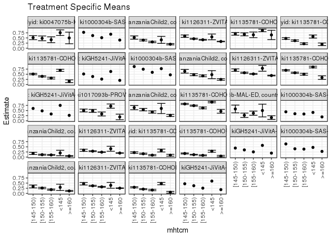

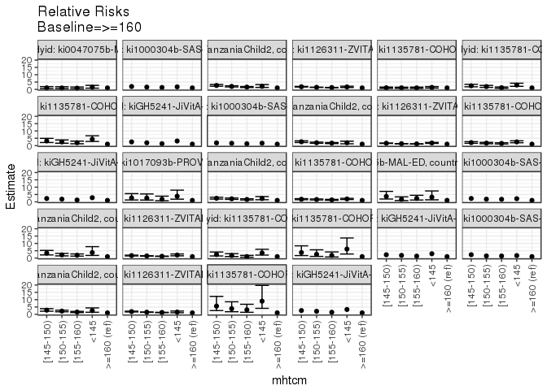

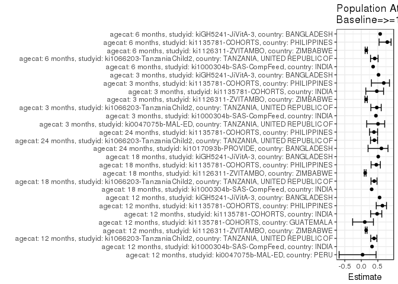

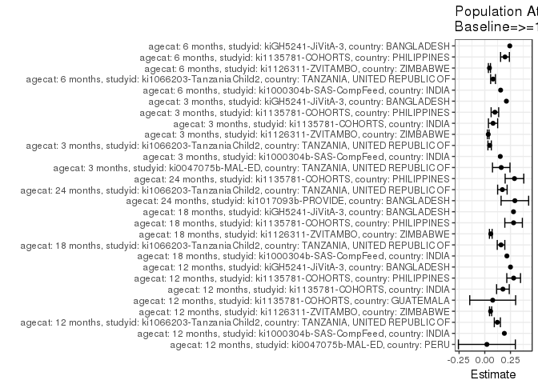

## Results Table

### Parameter: TSM

| agecat | studyid | country | intervention_level | baseline_level | estimate | ci_lower | ci_upper |
| --- | --- | --- | --- | --- | --- | --- | --- |
| 3 months | ki0047075b-MAL-ED | TANZANIA, UNITED REPUBLIC OF | >=160 | NA | 0.1562500 | 0.0671198 | 0.2453802 |
| 3 months | ki0047075b-MAL-ED | TANZANIA, UNITED REPUBLIC OF | <145 | NA | 0.5000000 | 0.1894954 | 0.8105046 |
| 3 months | ki0047075b-MAL-ED | TANZANIA, UNITED REPUBLIC OF | [145-150) | NA | 0.5769231 | 0.3866489 | 0.7671973 |
| 3 months | ki0047075b-MAL-ED | TANZANIA, UNITED REPUBLIC OF | [150-155) | NA | 0.2686567 | 0.1623110 | 0.3750025 |
| 3 months | ki0047075b-MAL-ED | TANZANIA, UNITED REPUBLIC OF | [155-160) | NA | 0.3707865 | 0.2702407 | 0.4713323 |
| 3 months | ki1000304b-SAS-CompFeed | INDIA | >=160 | NA | 0.1896552 | NA | NA |
| 3 months | ki1000304b-SAS-CompFeed | INDIA | <145 | NA | 0.4074074 | NA | NA |
| 3 months | ki1000304b-SAS-CompFeed | INDIA | [145-150) | NA | 0.4375000 | NA | NA |
| 3 months | ki1000304b-SAS-CompFeed | INDIA | [150-155) | NA | 0.3437500 | NA | NA |
| 3 months | ki1000304b-SAS-CompFeed | INDIA | [155-160) | NA | 0.3306452 | NA | NA |
| 3 months | ki1066203-TanzaniaChild2 | TANZANIA, UNITED REPUBLIC OF | >=160 | NA | 0.0534125 | 0.0364335 | 0.0703915 |
| 3 months | ki1066203-TanzaniaChild2 | TANZANIA, UNITED REPUBLIC OF | <145 | NA | 0.2000000 | 0.0674541 | 0.3325459 |
| 3 months | ki1066203-TanzaniaChild2 | TANZANIA, UNITED REPUBLIC OF | [145-150) | NA | 0.1793478 | 0.1239033 | 0.2347924 |
| 3 months | ki1066203-TanzaniaChild2 | TANZANIA, UNITED REPUBLIC OF | [150-155) | NA | 0.1171032 | 0.0923600 | 0.1418465 |
| 3 months | ki1066203-TanzaniaChild2 | TANZANIA, UNITED REPUBLIC OF | [155-160) | NA | 0.1044226 | 0.0834101 | 0.1254351 |
| 3 months | ki1126311-ZVITAMBO | ZIMBABWE | >=160 | NA | 0.1960984 | 0.1850045 | 0.2071922 |
| 3 months | ki1126311-ZVITAMBO | ZIMBABWE | <145 | NA | 0.4062500 | 0.2859187 | 0.5265813 |
| 3 months | ki1126311-ZVITAMBO | ZIMBABWE | [145-150) | NA | 0.3322785 | 0.2803417 | 0.3842153 |
| 3 months | ki1126311-ZVITAMBO | ZIMBABWE | [150-155) | NA | 0.2875616 | 0.2655467 | 0.3095765 |
| 3 months | ki1126311-ZVITAMBO | ZIMBABWE | [155-160) | NA | 0.2404409 | 0.2248945 | 0.2559874 |
| 3 months | ki1135781-COHORTS | INDIA | >=160 | NA | 0.0909091 | 0.0454929 | 0.1363253 |
| 3 months | ki1135781-COHORTS | INDIA | <145 | NA | 0.3173653 | 0.2467531 | 0.3879775 |
| 3 months | ki1135781-COHORTS | INDIA | [145-150) | NA | 0.2217822 | 0.1855385 | 0.2580259 |
| 3 months | ki1135781-COHORTS | INDIA | [150-155) | NA | 0.1622465 | 0.1336981 | 0.1907948 |
| 3 months | ki1135781-COHORTS | INDIA | [155-160) | NA | 0.0938272 | 0.0654214 | 0.1222329 |
| 3 months | ki1135781-COHORTS | PHILIPPINES | >=160 | NA | 0.0461538 | 0.0100802 | 0.0822275 |
| 3 months | ki1135781-COHORTS | PHILIPPINES | <145 | NA | 0.2844037 | 0.2354994 | 0.3333080 |
| 3 months | ki1135781-COHORTS | PHILIPPINES | [145-150) | NA | 0.1742739 | 0.1503233 | 0.1982244 |
| 3 months | ki1135781-COHORTS | PHILIPPINES | [150-155) | NA | 0.1173875 | 0.0986418 | 0.1361331 |
| 3 months | ki1135781-COHORTS | PHILIPPINES | [155-160) | NA | 0.0836653 | 0.0594402 | 0.1078905 |

[output cut: 110 more lines]

### Parameter: E(Y)

| agecat | studyid | country | intervention_level | baseline_level | estimate | ci_lower | ci_upper |
| --- | --- | --- | --- | --- | --- | --- | --- |
| 3 months | ki0047075b-MAL-ED | TANZANIA, UNITED REPUBLIC OF | NA | NA | 0.3164063 | 0.2593242 | 0.3734883 |
| 3 months | ki1000304b-SAS-CompFeed | INDIA | NA | NA | 0.3405276 | NA | NA |
| 3 months | ki1066203-TanzaniaChild2 | TANZANIA, UNITED REPUBLIC OF | NA | NA | 0.1005942 | 0.0884459 | 0.1127426 |
| 3 months | ki1126311-ZVITAMBO | ZIMBABWE | NA | NA | 0.2300570 | 0.2217358 | 0.2383782 |
| 3 months | ki1135781-COHORTS | INDIA | NA | NA | 0.1714744 | 0.1543953 | 0.1885534 |
| 3 months | ki1135781-COHORTS | PHILIPPINES | NA | NA | 0.1446335 | 0.1321610 | 0.1571060 |
| 3 months | kiGH5241-JiVitA-3 | BANGLADESH | NA | NA | 0.4034441 | NA | NA |
| 6 months | ki1000304b-SAS-CompFeed | INDIA | NA | NA | 0.4307692 | NA | NA |
| 6 months | ki1066203-TanzaniaChild2 | TANZANIA, UNITED REPUBLIC OF | NA | NA | 0.1986364 | 0.1819608 | 0.2153119 |
| 6 months | ki1126311-ZVITAMBO | ZIMBABWE | NA | NA | 0.2991857 | 0.2888998 | 0.3094716 |
| 6 months | ki1135781-COHORTS | PHILIPPINES | NA | NA | 0.2498218 | 0.2338012 | 0.2658424 |
| 6 months | kiGH5241-JiVitA-3 | BANGLADESH | NA | NA | 0.4254473 | NA | NA |
| 12 months | ki0047075b-MAL-ED | PERU | NA | NA | 0.5204461 | 0.4606342 | 0.5802580 |
| 12 months | ki1000304b-SAS-CompFeed | INDIA | NA | NA | 0.5866667 | NA | NA |
| 12 months | ki1066203-TanzaniaChild2 | TANZANIA, UNITED REPUBLIC OF | NA | NA | 0.3161914 | 0.2956216 | 0.3367613 |
| 12 months | ki1126311-ZVITAMBO | ZIMBABWE | NA | NA | 0.3846801 | 0.3742229 | 0.3951374 |
| 12 months | ki1135781-COHORTS | GUATEMALA | NA | NA | 0.7242026 | 0.6862259 | 0.7621793 |
| 12 months | ki1135781-COHORTS | INDIA | NA | NA | 0.3685637 | 0.3465451 | 0.3905822 |
| 12 months | ki1135781-COHORTS | PHILIPPINES | NA | NA | 0.4388125 | 0.4203024 | 0.4573225 |
| 12 months | kiGH5241-JiVitA-3 | BANGLADESH | NA | NA | 0.4519219 | NA | NA |
| 18 months | ki1000304b-SAS-CompFeed | INDIA | NA | NA | 0.6856369 | NA | NA |
| 18 months | ki1066203-TanzaniaChild2 | TANZANIA, UNITED REPUBLIC OF | NA | NA | 0.4040475 | 0.3786320 | 0.4294630 |
| 18 months | ki1126311-ZVITAMBO | ZIMBABWE | NA | NA | 0.4952317 | 0.4825554 | 0.5079080 |
| 18 months | ki1135781-COHORTS | PHILIPPINES | NA | NA | 0.6166413 | 0.5980630 | 0.6352197 |
| 18 months | kiGH5241-JiVitA-3 | BANGLADESH | NA | NA | 0.5437637 | NA | NA |
| 24 months | ki1017093b-PROVIDE | BANGLADESH | NA | NA | 0.4802065 | 0.4395469 | 0.5208662 |
| 24 months | ki1066203-TanzaniaChild2 | TANZANIA, UNITED REPUBLIC OF | NA | NA | 0.4330875 | 0.4015454 | 0.4646295 |
| 24 months | ki1135781-COHORTS | PHILIPPINES | NA | NA | 0.7525371 | 0.7358238 | 0.7692504 |

### Parameter: RR

| agecat | studyid | country | intervention_level | baseline_level | estimate | ci_lower | ci_upper |
| --- | --- | --- | --- | --- | --- | --- | --- |
| 3 months | ki0047075b-MAL-ED | TANZANIA, UNITED REPUBLIC OF | >=160 | >=160 | 1.0000000 | 1.0000000 | 1.000000 |
| 3 months | ki0047075b-MAL-ED | TANZANIA, UNITED REPUBLIC OF | <145 | >=160 | 3.2000000 | 1.3770108 | 7.436398 |
| 3 months | ki0047075b-MAL-ED | TANZANIA, UNITED REPUBLIC OF | [145-150) | >=160 | 3.6923077 | 1.9104474 | 7.136096 |
| 3 months | ki0047075b-MAL-ED | TANZANIA, UNITED REPUBLIC OF | [150-155) | >=160 | 1.7194030 | 0.8586906 | 3.442854 |
| 3 months | ki0047075b-MAL-ED | TANZANIA, UNITED REPUBLIC OF | [155-160) | >=160 | 2.3730337 | 1.2618295 | 4.462797 |
| 3 months | ki1000304b-SAS-CompFeed | INDIA | >=160 | >=160 | 1.0000000 | NA | NA |
| 3 months | ki1000304b-SAS-CompFeed | INDIA | <145 | >=160 | 2.1481481 | NA | NA |
| 3 months | ki1000304b-SAS-CompFeed | INDIA | [145-150) | >=160 | 2.3068182 | NA | NA |
| 3 months | ki1000304b-SAS-CompFeed | INDIA | [150-155) | >=160 | 1.8125000 | NA | NA |
| 3 months | ki1000304b-SAS-CompFeed | INDIA | [155-160) | >=160 | 1.7434018 | NA | NA |
| 3 months | ki1066203-TanzaniaChild2 | TANZANIA, UNITED REPUBLIC OF | >=160 | >=160 | 1.0000000 | 1.0000000 | 1.000000 |
| 3 months | ki1066203-TanzaniaChild2 | TANZANIA, UNITED REPUBLIC OF | <145 | >=160 | 3.7444444 | 1.7954377 | 7.809162 |
| 3 months | ki1066203-TanzaniaChild2 | TANZANIA, UNITED REPUBLIC OF | [145-150) | >=160 | 3.3577898 | 2.1551552 | 5.231527 |
| 3 months | ki1066203-TanzaniaChild2 | TANZANIA, UNITED REPUBLIC OF | [150-155) | >=160 | 2.1924328 | 1.4967713 | 3.211420 |
| 3 months | ki1066203-TanzaniaChild2 | TANZANIA, UNITED REPUBLIC OF | [155-160) | >=160 | 1.9550232 | 1.3420270 | 2.848017 |
| 3 months | ki1126311-ZVITAMBO | ZIMBABWE | >=160 | >=160 | 1.0000000 | 1.0000000 | 1.000000 |
| 3 months | ki1126311-ZVITAMBO | ZIMBABWE | <145 | >=160 | 2.0716645 | 1.5323431 | 2.800805 |
| 3 months | ki1126311-ZVITAMBO | ZIMBABWE | [145-150) | >=160 | 1.6944481 | 1.4349485 | 2.000876 |
| 3 months | ki1126311-ZVITAMBO | ZIMBABWE | [150-155) | >=160 | 1.4664150 | 1.3332624 | 1.612866 |
| 3 months | ki1126311-ZVITAMBO | ZIMBABWE | [155-160) | >=160 | 1.2261241 | 1.1251815 | 1.336123 |
| 3 months | ki1135781-COHORTS | INDIA | >=160 | >=160 | 1.0000000 | 1.0000000 | 1.000000 |
| 3 months | ki1135781-COHORTS | INDIA | <145 | >=160 | 3.4910176 | 2.0204267 | 6.031995 |
| 3 months | ki1135781-COHORTS | INDIA | [145-150) | >=160 | 2.4396037 | 1.4422546 | 4.126640 |
| 3 months | ki1135781-COHORTS | INDIA | [150-155) | >=160 | 1.7847112 | 1.0508475 | 3.031072 |
| 3 months | ki1135781-COHORTS | INDIA | [155-160) | >=160 | 1.0320987 | 0.5754761 | 1.851037 |
| 3 months | ki1135781-COHORTS | PHILIPPINES | >=160 | >=160 | 1.0000000 | 1.0000000 | 1.000000 |
| 3 months | ki1135781-COHORTS | PHILIPPINES | <145 | >=160 | 6.1620794 | 2.7680025 | 13.717915 |
| 3 months | ki1135781-COHORTS | PHILIPPINES | [145-150) | >=160 | 3.7759335 | 1.7075517 | 8.349776 |
| 3 months | ki1135781-COHORTS | PHILIPPINES | [150-155) | >=160 | 2.5433951 | 1.1454030 | 5.647670 |
| 3 months | ki1135781-COHORTS | PHILIPPINES | [155-160) | >=160 | 1.8127490 | 0.7876817 | 4.171811 |

[output cut: 110 more lines]

### Parameter: PAR

| agecat | studyid | country | intervention_level | baseline_level | estimate | ci_lower | ci_upper |
| --- | --- | --- | --- | --- | --- | --- | --- |
| 3 months | ki0047075b-MAL-ED | TANZANIA, UNITED REPUBLIC OF | >=160 | NA | 0.1601563 | 0.0751242 | 0.2451883 |
| 3 months | ki1000304b-SAS-CompFeed | INDIA | >=160 | NA | 0.1508724 | NA | NA |
| 3 months | ki1066203-TanzaniaChild2 | TANZANIA, UNITED REPUBLIC OF | >=160 | NA | 0.0471818 | 0.0307220 | 0.0636415 |
| 3 months | ki1126311-ZVITAMBO | ZIMBABWE | >=160 | NA | 0.0339586 | 0.0256480 | 0.0422693 |
| 3 months | ki1135781-COHORTS | INDIA | >=160 | NA | 0.0805653 | 0.0356769 | 0.1254536 |
| 3 months | ki1135781-COHORTS | PHILIPPINES | >=160 | NA | 0.0984797 | 0.0617896 | 0.1351697 |
| 3 months | kiGH5241-JiVitA-3 | BANGLADESH | >=160 | NA | 0.2103606 | NA | NA |
| 6 months | ki1000304b-SAS-CompFeed | INDIA | >=160 | NA | 0.1541735 | NA | NA |
| 6 months | ki1066203-TanzaniaChild2 | TANZANIA, UNITED REPUBLIC OF | >=160 | NA | 0.0805261 | 0.0571902 | 0.1038620 |
| 6 months | ki1126311-ZVITAMBO | ZIMBABWE | >=160 | NA | 0.0453295 | 0.0350874 | 0.0555716 |
| 6 months | ki1135781-COHORTS | PHILIPPINES | >=160 | NA | 0.1967245 | 0.1539604 | 0.2394886 |
| 6 months | kiGH5241-JiVitA-3 | BANGLADESH | >=160 | NA | 0.2432611 | NA | NA |
| 12 months | ki0047075b-MAL-ED | PERU | >=160 | NA | 0.0204461 | -0.2565730 | 0.2974652 |
| 12 months | ki1000304b-SAS-CompFeed | INDIA | >=160 | NA | 0.1904403 | NA | NA |
| 12 months | ki1066203-TanzaniaChild2 | TANZANIA, UNITED REPUBLIC OF | >=160 | NA | 0.1222413 | 0.0925700 | 0.1519126 |
| 12 months | ki1126311-ZVITAMBO | ZIMBABWE | >=160 | NA | 0.0566493 | 0.0461709 | 0.0671276 |
| 12 months | ki1135781-COHORTS | GUATEMALA | >=160 | NA | 0.0771438 | -0.1461191 | 0.3004068 |
| 12 months | ki1135781-COHORTS | INDIA | >=160 | NA | 0.1765107 | 0.1149643 | 0.2380572 |
| 12 months | ki1135781-COHORTS | PHILIPPINES | >=160 | NA | 0.2809177 | 0.2141739 | 0.3476616 |
| 12 months | kiGH5241-JiVitA-3 | BANGLADESH | >=160 | NA | 0.2501675 | NA | NA |
| 18 months | ki1000304b-SAS-CompFeed | INDIA | >=160 | NA | 0.2150486 | NA | NA |
| 18 months | ki1066203-TanzaniaChild2 | TANZANIA, UNITED REPUBLIC OF | >=160 | NA | 0.1582241 | 0.1214520 | 0.1949962 |
| 18 months | ki1126311-ZVITAMBO | ZIMBABWE | >=160 | NA | 0.0585141 | 0.0453588 | 0.0716693 |
| 18 months | ki1135781-COHORTS | PHILIPPINES | >=160 | NA | 0.2803582 | 0.1950124 | 0.3657039 |
| 18 months | kiGH5241-JiVitA-3 | BANGLADESH | >=160 | NA | 0.2792134 | NA | NA |
| 24 months | ki1017093b-PROVIDE | BANGLADESH | >=160 | NA | 0.2927065 | 0.1587106 | 0.4267025 |
| 24 months | ki1066203-TanzaniaChild2 | TANZANIA, UNITED REPUBLIC OF | >=160 | NA | 0.1712693 | 0.1251044 | 0.2174342 |
| 24 months | ki1135781-COHORTS | PHILIPPINES | >=160 | NA | 0.2889007 | 0.1982304 | 0.3795711 |

### Parameter: PAF

| agecat | studyid | country | intervention_level | baseline_level | estimate | ci_lower | ci_upper |
| --- | --- | --- | --- | --- | --- | --- | --- |
| 3 months | ki0047075b-MAL-ED | TANZANIA, UNITED REPUBLIC OF | >=160 | NA | 0.5061728 | 0.1636392 | 0.7084210 |
| 3 months | ki1000304b-SAS-CompFeed | INDIA | >=160 | NA | 0.4430549 | NA | NA |
| 3 months | ki1066203-TanzaniaChild2 | TANZANIA, UNITED REPUBLIC OF | >=160 | NA | 0.4690305 | 0.2893767 | 0.6032658 |
| 3 months | ki1126311-ZVITAMBO | ZIMBABWE | >=160 | NA | 0.1476096 | 0.1109115 | 0.1827930 |
| 3 months | ki1135781-COHORTS | INDIA | >=160 | NA | 0.4698385 | 0.1367052 | 0.6744204 |
| 3 months | ki1135781-COHORTS | PHILIPPINES | >=160 | NA | 0.6808910 | 0.3068444 | 0.8530914 |
| 3 months | kiGH5241-JiVitA-3 | BANGLADESH | >=160 | NA | 0.5214119 | NA | NA |
| 6 months | ki1000304b-SAS-CompFeed | INDIA | >=160 | NA | 0.3579027 | NA | NA |
| 6 months | ki1066203-TanzaniaChild2 | TANZANIA, UNITED REPUBLIC OF | >=160 | NA | 0.4053947 | 0.2797925 | 0.5090922 |
| 6 months | ki1126311-ZVITAMBO | ZIMBABWE | >=160 | NA | 0.1515096 | 0.1166903 | 0.1849563 |
| 6 months | ki1135781-COHORTS | PHILIPPINES | >=160 | NA | 0.7874591 | 0.5387885 | 0.9020544 |
| 6 months | kiGH5241-JiVitA-3 | BANGLADESH | >=160 | NA | 0.5717772 | NA | NA |
| 12 months | ki0047075b-MAL-ED | PERU | >=160 | NA | 0.0392857 | -0.6719349 | 0.4479618 |
| 12 months | ki1000304b-SAS-CompFeed | INDIA | >=160 | NA | 0.3246141 | NA | NA |
| 12 months | ki1066203-TanzaniaChild2 | TANZANIA, UNITED REPUBLIC OF | >=160 | NA | 0.3866052 | 0.2869181 | 0.4723563 |
| 12 months | ki1126311-ZVITAMBO | ZIMBABWE | >=160 | NA | 0.1472633 | 0.1195644 | 0.1740909 |
| 12 months | ki1135781-COHORTS | GUATEMALA | >=160 | NA | 0.1065224 | -0.2618991 | 0.3673803 |
| 12 months | ki1135781-COHORTS | INDIA | >=160 | NA | 0.4789151 | 0.2833903 | 0.6210915 |
| 12 months | ki1135781-COHORTS | PHILIPPINES | >=160 | NA | 0.6401772 | 0.4524797 | 0.7635294 |
| 12 months | kiGH5241-JiVitA-3 | BANGLADESH | >=160 | NA | 0.5535636 | NA | NA |
| 18 months | ki1000304b-SAS-CompFeed | INDIA | >=160 | NA | 0.3136480 | NA | NA |
| 18 months | ki1066203-TanzaniaChild2 | TANZANIA, UNITED REPUBLIC OF | >=160 | NA | 0.3915977 | 0.2941084 | 0.4756230 |
| 18 months | ki1126311-ZVITAMBO | ZIMBABWE | >=160 | NA | 0.1181549 | 0.0910577 | 0.1444443 |
| 18 months | ki1135781-COHORTS | PHILIPPINES | >=160 | NA | 0.4546535 | 0.2964433 | 0.5772867 |
| 18 months | kiGH5241-JiVitA-3 | BANGLADESH | >=160 | NA | 0.5134830 | NA | NA |
| 24 months | ki1017093b-PROVIDE | BANGLADESH | >=160 | NA | 0.6095430 | 0.2048348 | 0.8082704 |
| 24 months | ki1066203-TanzaniaChild2 | TANZANIA, UNITED REPUBLIC OF | >=160 | NA | 0.3954612 | 0.2792459 | 0.4929378 |
| 24 months | ki1135781-COHORTS | PHILIPPINES | >=160 | NA | 0.3839023 | 0.2498227 | 0.4940178 |